# Cyclistic Member vs Casual Rider Analysis

John Judge

2022-06-24

## Identify how member and casual riders use cycles differently

## Give credit where credit is due:

This script follows the [Divvy Exercise R Script.](https://docs.google.com/document/d/1TTj5KNKf4BWvEORGm10oNbpwTRk1hamsWJGj6qRWpuI/edit)

It is NOT strictly copy/paste, but without the help provided by that script, I wouldn’t have been able to do some of what’s below.

## Load Libraries And Set Working Directory

```r
library("tidyverse")
library("lubridate")
```

```r
library("anytime")
library("ggplot2")
```

```r
setwd("C:/Users/jj/Documents/Google Data Analytics Cert/capstone project/Cyclistic Member vs Casual Rider Analysis")
```

## Set Up Data Frame

Read in Data From Separate Files

```r
data_202205 <- read.csv('202205-divvy-tripdata.csv')
data_202204 <- read.csv('202204-divvy-tripdata.csv')
data_202203 <- read.csv('202203-divvy-tripdata.csv')
data_202202 <- read.csv('202202-divvy-tripdata.csv')
data_202201 <- read.csv('202201-divvy-tripdata.csv')
data_202112 <- read.csv('202112-divvy-tripdata.csv')
data_202111 <- read.csv('202111-divvy-tripdata.csv')
data_202110 <- read.csv('202110-divvy-tripdata.csv')
data_202109 <- read.csv('202109-divvy-tripdata.csv')
data_202108 <- read.csv('202108-divvy-tripdata.csv')
data_202107 <- read.csv('202107-divvy-tripdata.csv')
data_202106 <- read.csv('202106-divvy-tripdata.csv')
```

Output Column Names For Each File To Ensure They are all the Same

```r
colnames(data_202205)
```

```
##  [1] "ride_id"            "rideable_type"      "started_at"
##  [4] "ended_at"           "start_station_name" "start_station_id"
##  [7] "end_station_name"   "end_station_id"     "start_lat"
## [10] "start_lng"          "end_lat"            "end_lng"
## [13] "member_casual"
```

```r
colnames(data_202204)
```

```
##  [1] "ride_id"            "rideable_type"      "started_at"
##  [4] "ended_at"           "start_station_name" "start_station_id"
##  [7] "end_station_name"   "end_station_id"     "start_lat"
## [10] "start_lng"          "end_lat"            "end_lng"
## [13] "member_casual"
```

```r
colnames(data_202203)
```

```
##  [1] "ride_id"            "rideable_type"      "started_at"
##  [4] "ended_at"           "start_station_name" "start_station_id"
##  [7] "end_station_name"   "end_station_id"     "start_lat"
## [10] "start_lng"          "end_lat"            "end_lng"
## [13] "member_casual"
```

```r
colnames(data_202202)
```

```
##  [1] "ride_id"            "rideable_type"      "started_at"
##  [4] "ended_at"           "start_station_name" "start_station_id"
##  [7] "end_station_name"   "end_station_id"     "start_lat"
## [10] "start_lng"          "end_lat"            "end_lng"
## [13] "member_casual"
```

```r
colnames(data_202201)
```

```
##  [1] "ride_id"            "rideable_type"      "started_at"
##  [4] "ended_at"           "start_station_name" "start_station_id"
##  [7] "end_station_name"   "end_station_id"     "start_lat"
## [10] "start_lng"          "end_lat"            "end_lng"
## [13] "member_casual"
```

```r
colnames(data_202112)
```

```
##  [1] "ride_id"            "rideable_type"      "started_at"
##  [4] "ended_at"           "start_station_name" "start_station_id"
##  [7] "end_station_name"   "end_station_id"     "start_lat"
## [10] "start_lng"          "end_lat"            "end_lng"
## [13] "member_casual"
```

```r
colnames(data_202111)
```

```
##  [1] "ride_id"            "rideable_type"      "started_at"
##  [4] "ended_at"           "start_station_name" "start_station_id"
##  [7] "end_station_name"   "end_station_id"     "start_lat"
## [10] "start_lng"          "end_lat"            "end_lng"
## [13] "member_casual"
```

```r
colnames(data_202110)
```

```
##  [1] "ride_id"            "rideable_type"      "started_at"
##  [4] "ended_at"           "start_station_name" "start_station_id"
##  [7] "end_station_name"   "end_station_id"     "start_lat"
## [10] "start_lng"          "end_lat"            "end_lng"
## [13] "member_casual"
```

```r
colnames(data_202109)
```

```
##  [1] "ride_id"            "rideable_type"      "started_at"
##  [4] "ended_at"           "start_station_name" "start_station_id"
##  [7] "end_station_name"   "end_station_id"     "start_lat"
## [10] "start_lng"          "end_lat"            "end_lng"
## [13] "member_casual"
```

```r
colnames(data_202108)
```

```
##  [1] "ride_id"            "rideable_type"      "started_at"
##  [4] "ended_at"           "start_station_name" "start_station_id"
##  [7] "end_station_name"   "end_station_id"     "start_lat"
## [10] "start_lng"          "end_lat"            "end_lng"
## [13] "member_casual"
```

```r
colnames(data_202107)
```

```
##  [1] "ride_id"            "rideable_type"      "started_at"
##  [4] "ended_at"           "start_station_name" "start_station_id"
##  [7] "end_station_name"   "end_station_id"     "start_lat"
## [10] "start_lng"          "end_lat"            "end_lng"
## [13] "member_casual"
```

```r
colnames(data_202106)
```

```
##  [1] "ride_id"            "rideable_type"      "started_at"
##  [4] "ended_at"           "start_station_name" "start_station_id"
##  [7] "end_station_name"   "end_station_id"     "start_lat"
## [10] "start_lng"          "end_lat"            "end_lng"
## [13] "member_casual"
```

Combine Files Into Single Data Frame

```r
all_trips <- bind_rows(data_202205, data_202204, data_202203, data_202202,
                       data_202201, data_202112, data_202111, data_202110,
                       data_202109, data_202108, data_202107, data_202106)
```

## Inspect Newly Created Data Frame

check columns, number of rows, structure and data types

```r
colnames(all_trips)
```

```
##  [1] "ride_id"            "rideable_type"      "started_at"
##  [4] "ended_at"           "start_station_name" "start_station_id"
##  [7] "end_station_name"   "end_station_id"     "start_lat"
## [10] "start_lng"          "end_lat"            "end_lng"
## [13] "member_casual"
```

```r
nrow(all_trips)
```

```
## [1] 5860776
```

```r
head(all_trips)
```

```
##            ride_id rideable_type      started_at        ended_at
## 1 EC2DE40644C6B0F4  classic_bike 5/23/2022 23:06 5/23/2022 23:40
## 2 1C31AD03897EE385  classic_bike  5/11/2022 8:53  5/11/2022 9:31
## 3 1542FBEC830415CF  classic_bike 5/26/2022 18:36 5/26/2022 18:58
## 4 6FF59852924528F8  classic_bike  5/10/2022 7:30  5/10/2022 7:38
## 5 483C52CAAE12E3AC  classic_bike 5/10/2022 17:31 5/10/2022 17:36
## 6 C0A3AA5A614DCE01  classic_bike  5/4/2022 14:48  5/4/2022 14:56
##                  start_station_name start_station_id
## 1            Wabash Ave & Grand Ave     TA1307000117
## 2 DuSable Lake Shore Dr & Monroe St            13300
## 3           Clinton St & Madison St     TA1305000032
## 4           Clinton St & Madison St     TA1305000032
## 5           Clinton St & Madison St     TA1305000032
## 6           Carpenter St & Huron St            13196
##                end_station_name end_station_id start_lat start_lng  end_lat
## 1        Halsted St & Roscoe St   TA1309000025  41.89147 -87.62676 41.94367
## 2   Field Blvd & South Water St          15534  41.88096 -87.61674 41.88635
## 3       Wood St & Milwaukee Ave          13221  41.88224 -87.64107 41.90765
## 4        Clark St & Randolph St   TA1305000030  41.88224 -87.64107 41.88458
## 5           Morgan St & Lake St   TA1306000015  41.88224 -87.64107 41.88578
## 6 Sangamon St & Washington Blvd          13409  41.89456 -87.65345 41.88316
##     end_lng member_casual
## 1 -87.64895        member
## 2 -87.61752        member
## 3 -87.67255        member
## 4 -87.63189        member
## 5 -87.65102        member
## 6 -87.65110        member
```

```r
tail(all_trips)
```

```
##                  ride_id rideable_type          started_at            ended_at
## 5860771 547E5403EE6777B2 electric_bike 2021-06-12 15:31:50 2021-06-12 16:38:22
## 5860772 CB282292CCFCE74F electric_bike 2021-06-14 00:17:31 2021-06-14 00:56:46
## 5860773 47BD346FAFB9BE6D  classic_bike 2021-06-30 17:35:10 2021-06-30 17:43:20
## 5860774 52467C23D17C6AFE  classic_bike 2021-06-13 19:24:30 2021-06-13 19:34:11
## 5860775 7DF6D74420D7D9E6 electric_bike 2021-06-08 15:44:28 2021-06-08 16:15:01
## 5860776 0C01F8BA99E512E5 electric_bike 2021-06-03 16:18:38 2021-06-03 16:47:49
##             start_station_name start_station_id         end_station_name
## 5860771     Wells St & Polk St           SL-011
## 5860772     Wells St & Polk St           SL-011
## 5860773 Clark St & Chicago Ave            13303 Kingsbury St & Kinzie St
## 5860774  Indiana Ave & 26th St     TA1307000005       State St & 19th St
## 5860775 Clark St & Chicago Ave            13303
## 5860776 Clark St & Chicago Ave            13303
##         end_station_id start_lat start_lng  end_lat   end_lng member_casual
## 5860771                 41.87262 -87.63377 41.86000 -87.61000        casual
## 5860772                 41.87241 -87.63371 41.88000 -87.62000        casual
## 5860773   KA1503000043  41.89675 -87.63089 41.88918 -87.63851        member
## 5860774         SL-013  41.84569 -87.62248 41.85659 -87.62754        member
## 5860775                 41.89649 -87.63061 41.94000 -87.71000        member
## 5860776                 41.89660 -87.63087 41.94000 -87.71000        member
```

```r
str(all_trips)
```

```
## 'data.frame':    5860776 obs. of  13 variables:
##  $ ride_id           : chr  "EC2DE40644C6B0F4" "1C31AD03897EE385" "1542FBEC830415CF" "6FF59852924528F8" ...
##  $ rideable_type     : chr  "classic_bike" "classic_bike" "classic_bike" "classic_bike" ...
##  $ started_at        : chr  "5/23/2022 23:06" "5/11/2022 8:53" "5/26/2022 18:36" "5/10/2022 7:30" ...
##  $ ended_at          : chr  "5/23/2022 23:40" "5/11/2022 9:31" "5/26/2022 18:58" "5/10/2022 7:38" ...
##  $ start_station_name: chr  "Wabash Ave & Grand Ave" "DuSable Lake Shore Dr & Monroe St" "Clinton St & Madison St" "Clinton St & Madison St" ...
##  $ start_station_id  : chr  "TA1307000117" "13300" "TA1305000032" "TA1305000032" ...
##  $ end_station_name  : chr  "Halsted St & Roscoe St" "Field Blvd & South Water St" "Wood St & Milwaukee Ave" "Clark St & Randolph St" ...
##  $ end_station_id    : chr  "TA1309000025" "15534" "13221" "TA1305000030" ...
##  $ start_lat         : num  41.9 41.9 41.9 41.9 41.9 ...
##  $ start_lng         : num  -87.6 -87.6 -87.6 -87.6 -87.6 ...
##  $ end_lat           : num  41.9 41.9 41.9 41.9 41.9 ...
##  $ end_lng           : num  -87.6 -87.6 -87.7 -87.6 -87.7 ...
##  $ member_casual     : chr  "member" "member" "member" "member" ...
```

```r
summary(all_trips)
```

```
##    ride_id          rideable_type       started_at          ended_at
##  Length:5860776     Length:5860776     Length:5860776     Length:5860776
##  Class :character   Class :character   Class :character   Class :character
##  Mode  :character   Mode  :character   Mode  :character   Mode  :character
##
##
##
##
##  start_station_name start_station_id   end_station_name   end_station_id
##  Length:5860776     Length:5860776     Length:5860776     Length:5860776
##  Class :character   Class :character   Class :character   Class :character
##  Mode  :character   Mode  :character   Mode  :character   Mode  :character
##
##
##
##
##    start_lat       start_lng         end_lat         end_lng
##  Min.   :41.64   Min.   :-87.84   Min.   :41.39   Min.   :-88.97
##  1st Qu.:41.88   1st Qu.:-87.66   1st Qu.:41.88   1st Qu.:-87.66
##  Median :41.90   Median :-87.64   Median :41.90   Median :-87.64
##  Mean   :41.90   Mean   :-87.65   Mean   :41.90   Mean   :-87.65
##  3rd Qu.:41.93   3rd Qu.:-87.63   3rd Qu.:41.93   3rd Qu.:-87.63
##  Max.   :45.64   Max.   :-73.80   Max.   :42.17   Max.   :-87.49
##                                   NA's   :5036    NA's   :5036
##  member_casual
##  Length:5860776
##  Class :character
##  Mode  :character
##
##
##
##
```

First attempt at view(all_trips) crashed RStudio!!! No wonder, over 5M records :)

Create a slice (output not included, eval set to FALSE)

```r
all_trips_v0.1 <- slice(all_trips, 1:100)
view(all_trips_v0.1)
```

Inspect rideable_type and member_casual column values to ensure there are no slight variations in spelling/abbreviation throughout the dataset

```r
unique(all_trips$rideable_type)
```

[1] “classic_bike” “docked_bike” “electric_bike”

```r
unique(all_trips$member_casual)
```

[1] “member” “casual”

Inspect start and end station names for slight variations create a list to view since theres over 1000 unique values Output not included, eval set to FALSE

```r
start_station_names <- sort(unique(all_trips$start_station_name))
end_station_names <- sort(unique(all_trips$end_station_name))
view(start_station_names)
view(end_station_names)
```

There’s probably a better way to do that. This requires scrolling and looking for slight variants.

check ride_id column for duplicated IDs

```r
sum(duplicated(all_trips$ride_id))
```

```
## [1] 0
```

## Add Fields to Enable Aggregating Data

add date related fields

```r
all_trips$date <- anydate(all_trips$started_at)
all_trips$day <- format(as.Date(all_trips$date), "%d")
all_trips$weekday <- format(as.Date(all_trips$date), "%A")
all_trips$month <- format(as.Date(all_trips$date), "%b")
all_trips$ridelength <- difftime(anytime(all_trips$ended_at), anytime(all_trips$started_at), units = "min")
```

create and view a slice of the data frame Output not included, eval set to FALSE

```r
all_trips_v1 <- slice(all_trips,1:100)
view(all_trips_v1)
```

convert ridelength column to numeric to enable calcs

```r
all_trips$ridelength <- as.numeric(all_trips$ridelength)
```

Inspect min, max, median and mean for ridelength column

```r
summary(all_trips$ridelength)
```

```
##     Min.  1st Qu.   Median     Mean  3rd Qu.     Max.
##   -58.03     6.12    11.13    21.02    20.43 55944.15
```

## Create A New Data Frame To Enable Analysis Of Valid Values

Exclude ride_length less than 1, since view() showed records with 0 mins and the summary() function showed min value is less than 0

NOTE - 0 min ride lengths do NOT have the same start and stop times!!!

ALSO - max value of 55944.15 (given a median of 11.13 and mean of 21.02) seems odd.

Arbitrarily sub-setting data at this point for rides greater than 1 day and 1 week for closer look

### Create New Data Frames

data frame for all non-negative values

```r
all_trips_v2 <- all_trips[!(all_trips$ridelength < 1),]
```

create new data frame to view trips longer than 1 week

```r
all_trips_v3 <- all_trips[(all_trips$ridelength > 10080),]
```

create new data frame to view trips longer than 1 day

```r
all_trips_v4 <- all_trips[(all_trips$ridelength > 1440),]
```

Review rides greater than a day and week Output not included, eval set to FALSE

```r
View(all_trips_v3)
View(all_trips_v4)
```

## Descriptive Analysis

Overall data set

```r
summary(all_trips_v2$ridelength)
```

```
##     Min.  1st Qu.   Median     Mean  3rd Qu.     Max.
##     1.00     6.58    11.58    21.74    21.00 55944.15
```

```r
sd(all_trips_v2$ridelength)
```

```
## [1] 168.5135
```

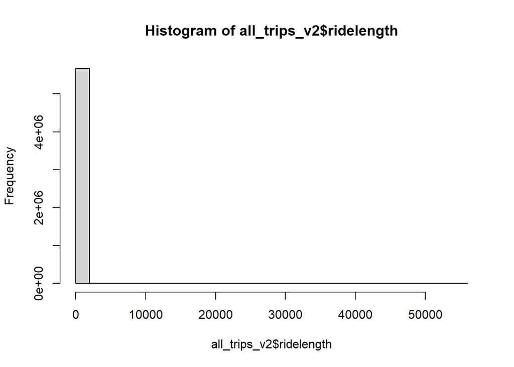

```r
hist(all_trips_v2$ridelength)
```

Max ride length of 55944.15 mins is troubling. With only 4,338 rides greater than a day and 301 rides greater than a week, the mean is skewed slightly with these data points in the set. Greater than a day seems like atypical riders, given there are 5M total records in the data set.

Pare down the data set to rides that aren’t greater than a day and not less than 0

```r
all_trips_v2.1 <- all_trips[!(all_trips$ridelength > 1440) & !(all_trips$ridelength < 1),]
```

Review distribution of pared down data set

```r
summary(all_trips_v2.1$ridelength)
```

```
##     Min.  1st Qu.   Median     Mean  3rd Qu.     Max.
##    1.000    6.583   11.583   19.328   20.950 1440.000
```

```r
sd(all_trips_v2.1$ridelength)
```

```
## [1] 39.72181
```

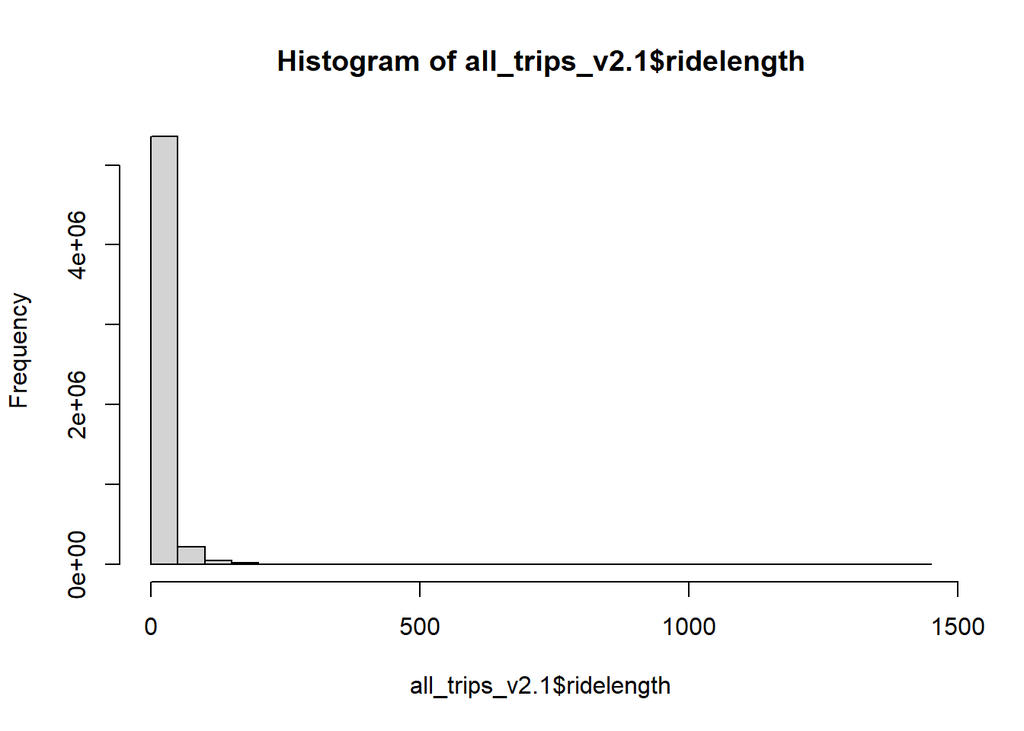

```r
hist(all_trips_v2.1$ridelength)
```

Still a significant spread in the data, 3rd quartile is only about 21 mins and the max is 1440 mins. There is an incredibly long right tail in the distribution

## Calculate The Mild Outlier Thresholds

### Determine a suitable upper bound and possibly show a different group of ride characteristics based on ride length

Create a value so I can manually check the math the code is doing…

```r
ridelength_IQR <- IQR(all_trips_v2.1$ridelength)
```

Calculate lower and upper thresholds

```r
if(quantile(all_trips_v2.1$ridelength, probs = .25, na.rm = TRUE)-
  (1.5 * IQR(all_trips_v2.1$ridelength)) < 0)
  {
  lower_threshold <- 0
  }else {
    lower_threshold <- quantile(all_trips_v2.1$ridelength, probs = .25, na.rm = TRUE)-
      (1.5 * IQR(all_trips_v2.1$ridelength))
  }

upper_threshold <- quantile(all_trips_v2.1$ridelength, probs = .75, na.rm = TRUE) +
  (1.5 * IQR(all_trips_v2.1$ridelength))
```

Create data frames for both sides of the upper threshold to enable separate reviews

```r
all_trips_v2.2 <- all_trips_v2.1[(all_trips_v2.1$ridelength < 42.5),]
all_trips_v2.3 <- all_trips_v2.1[!(all_trips_v2.1$ridelength < 42.5),]
```

## Second Descriptive Analysis

Compare mean median min and max for casual vs member riders first for overall data set

```r
aggregate(all_trips_v2.1$ridelength ~ all_trips_v2.1$member_casual, FUN = mean)
```

```
##   all_trips_v2.1$member_casual all_trips_v2.1$ridelength
## 1                       casual                  26.70021
## 2                       member                  13.55395
```

```r
aggregate(all_trips_v2.1$ridelength ~ all_trips_v2.1$member_casual, FUN = median)
```

```
##   all_trips_v2.1$member_casual all_trips_v2.1$ridelength
## 1                       casual                 15.550000
## 2                       member                  9.266667
```

```r
aggregate(all_trips_v2.1$ridelength ~ all_trips_v2.1$member_casual, FUN = min)
```

```
##   all_trips_v2.1$member_casual all_trips_v2.1$ridelength
## 1                       casual                         1
## 2                       member                         1
```

```r
aggregate(all_trips_v2.1$ridelength ~ all_trips_v2.1$member_casual, FUN = max)
```

```
##   all_trips_v2.1$member_casual all_trips_v2.1$ridelength
## 1                       casual                      1440
## 2                       member                      1440
```

Review rides by day of week, all rides

I WILL have order!

```r
all_trips_v2.1$weekday <- ordered(all_trips_v2.1$weekday,
  levels=c("Sunday", "Monday", "Tuesday", "Wednesday", "Thursday", "Friday", "Saturday"))

aggregate(all_trips_v2.1$ridelength ~ all_trips_v2.1$member_casual + all_trips_v2.1$weekday, FUN = mean)
```

```
##    all_trips_v2.1$member_casual all_trips_v2.1$weekday
## 1                        casual                 Sunday
## 2                        member                 Sunday
## 3                        casual                 Monday
## 4                        member                 Monday
## 5                        casual                Tuesday
## 6                        member                Tuesday
## 7                        casual              Wednesday
## 8                        member              Wednesday
## 9                        casual               Thursday
## 10                       member               Thursday
## 11                       casual                 Friday
## 12                       member                 Friday
## 13                       casual               Saturday
## 14                       member               Saturday
##    all_trips_v2.1$ridelength
## 1                   30.84536
## 2                   15.59903
## 3                   27.47138
## 4                   13.24454
## 5                   23.98334
## 6                   12.70062
## 7                   23.00492
## 8                   12.64782
## 9                   23.61267
## 10                  12.87350
## 11                  24.67424
## 12                  13.12223
## 13                  29.15718
## 14                  15.33174
```

Compare mean median max and min for data subset rides less than 42.5 mins

```r
aggregate(all_trips_v2.2$ridelength ~ all_trips_v2.2$member_casual, FUN = mean)
```

```
##   all_trips_v2.2$member_casual all_trips_v2.2$ridelength
## 1                       casual                  15.72415
## 2                       member                  11.58646
```

```r
aggregate(all_trips_v2.2$ridelength ~ all_trips_v2.2$member_casual, FUN = median)
```

```
##   all_trips_v2.2$member_casual all_trips_v2.2$ridelength
## 1                       casual                 13.416667
## 2                       member                  9.033333
```

```r
aggregate(all_trips_v2.2$ridelength ~ all_trips_v2.2$member_casual, FUN = min)
```

```
##   all_trips_v2.2$member_casual all_trips_v2.2$ridelength
## 1                       casual                         1
## 2                       member                         1
```

```r
aggregate(all_trips_v2.2$ridelength ~ all_trips_v2.2$member_casual, FUN = max)
```

```
##   all_trips_v2.2$member_casual all_trips_v2.2$ridelength
## 1                       casual                  42.48333
## 2                       member                  42.48333
```

Review rides by day of week rides less than 42.5 mins

```r
all_trips_v2.2$weekday <- ordered(all_trips_v2.2$weekday,
                                  levels=c("Sunday", "Monday", "Tuesday", "Wednesday", "Thursday", "Friday", "Saturday"))

aggregate(all_trips_v2.2$ridelength ~ all_trips_v2.2$member_casual + all_trips_v2.2$weekday, FUN = mean)
```

```
##    all_trips_v2.2$member_casual all_trips_v2.2$weekday
## 1                        casual                 Sunday
## 2                        member                 Sunday
## 3                        casual                 Monday
## 4                        member                 Monday
## 5                        casual                Tuesday
## 6                        member                Tuesday
## 7                        casual              Wednesday
## 8                        member              Wednesday
## 9                        casual               Thursday
## 10                       member               Thursday
## 11                       casual                 Friday
## 12                       member                 Friday
## 13                       casual               Saturday
## 14                       member               Saturday
##    all_trips_v2.2$ridelength
## 1                   16.93465
## 2                   12.63711
## 3                   15.60677
## 4                   11.27215
## 5                   14.68396
## 6                   11.09348
## 7                   14.68161
## 8                   11.21518
## 9                   14.71697
## 10                  11.21732
## 11                  15.31521
## 12                  11.38621
## 13                  16.81013
## 14                  12.64895
```

Compare mean median max and min for data subset rides more than 42.5 mins

```r
aggregate(all_trips_v2.3$ridelength ~ all_trips_v2.3$member_casual, FUN = mean)
```

```
##   all_trips_v2.3$member_casual all_trips_v2.3$ridelength
## 1                       casual                  95.41333
## 2                       member                  97.26408
```

```r
aggregate(all_trips_v2.3$ridelength ~ all_trips_v2.3$member_casual, FUN = median)
```

```
##   all_trips_v2.3$member_casual all_trips_v2.3$ridelength
## 1                       casual                  66.06667
## 2                       member                  51.98333
```

```r
aggregate(all_trips_v2.3$ridelength ~ all_trips_v2.3$member_casual, FUN = min)
```

```
##   all_trips_v2.3$member_casual all_trips_v2.3$ridelength
## 1                       casual                      42.5
## 2                       member                      42.5
```

```r
aggregate(all_trips_v2.3$ridelength ~ all_trips_v2.3$member_casual, FUN = max)
```

```
##   all_trips_v2.3$member_casual all_trips_v2.3$ridelength
## 1                       casual                      1440
## 2                       member                      1440
```

Review rides by day of week rides more than 42.5 mins

```r
all_trips_v2.3$weekday <- ordered(all_trips_v2.3$weekday,
                                  levels=c("Sunday", "Monday", "Tuesday", "Wednesday", "Thursday", "Friday", "Saturday"))

aggregate(all_trips_v2.3$ridelength ~ all_trips_v2.3$member_casual + all_trips_v2.3$weekday, FUN = mean)
```

```
##    all_trips_v2.3$member_casual all_trips_v2.3$weekday
## 1                        casual                 Sunday
## 2                        member                 Sunday
## 3                        casual                 Monday
## 4                        member                 Monday
## 5                        casual                Tuesday
## 6                        member                Tuesday
## 7                        casual              Wednesday
## 8                        member              Wednesday
## 9                        casual               Thursday
## 10                       member               Thursday
## 11                       casual                 Friday
## 12                       member                 Friday
## 13                       casual               Saturday
## 14                       member               Saturday
##    all_trips_v2.3$ridelength
## 1                   96.59543
## 2                   95.08171
## 3                   96.34471
## 4                  102.13266
## 5                   97.25043
## 6                  103.62431
## 7                   92.56036
## 8                   91.99042
## 9                   97.24311
## 10                 101.86083
## 11                  93.77694
## 12                  94.60003
## 13                  94.26715
## 14                  94.23342
```

## Create Plots And Visualize Data

Number of rides by day and by member type

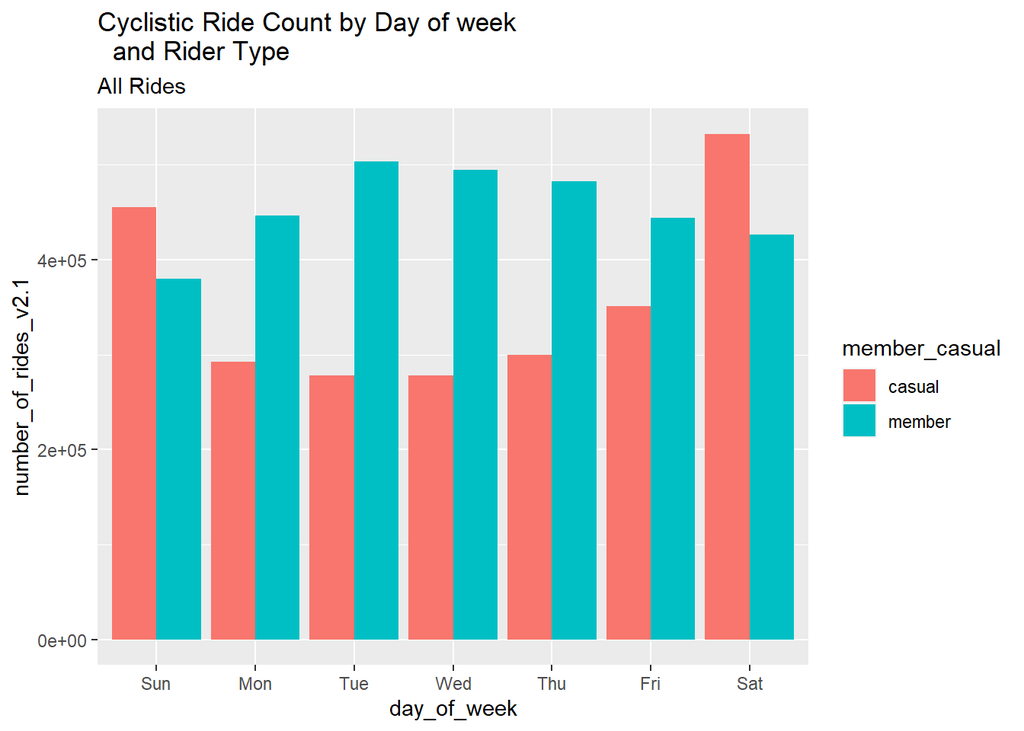

average ride length by day and by member type

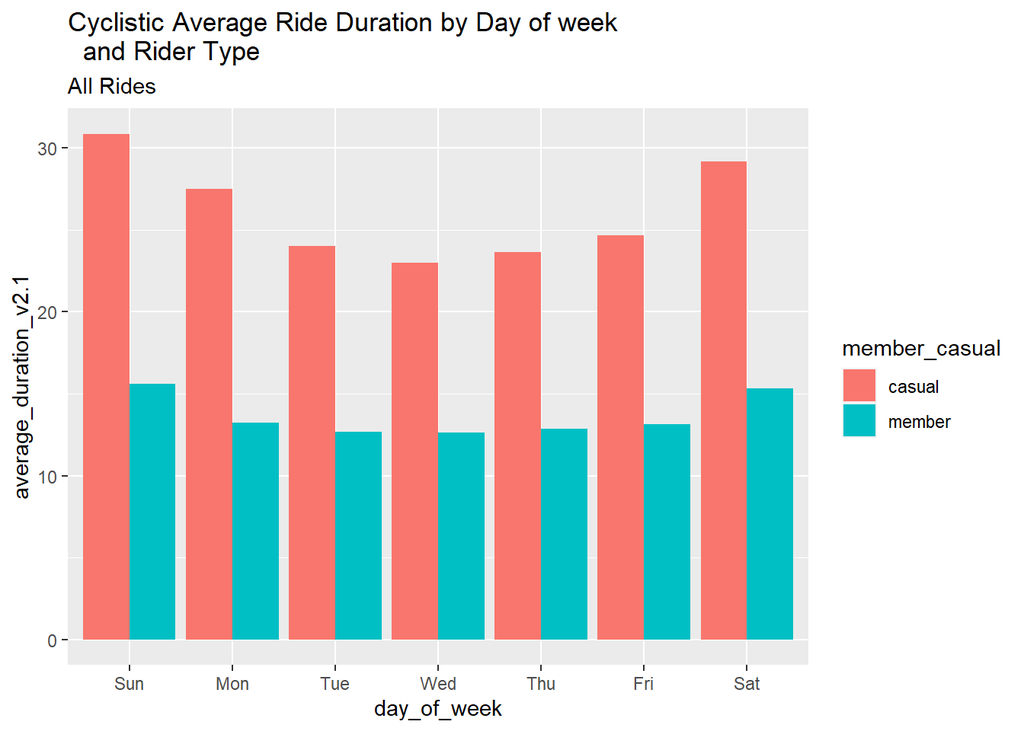

Ride length by rideable type and member type

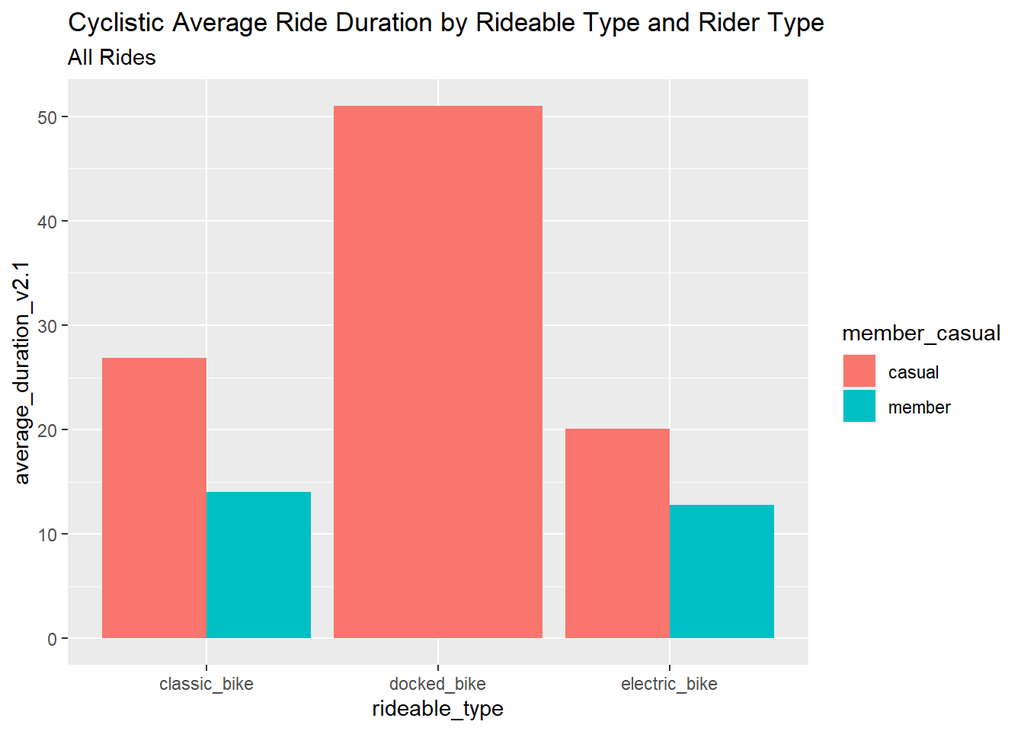

Ride Count by Month and Rider Type

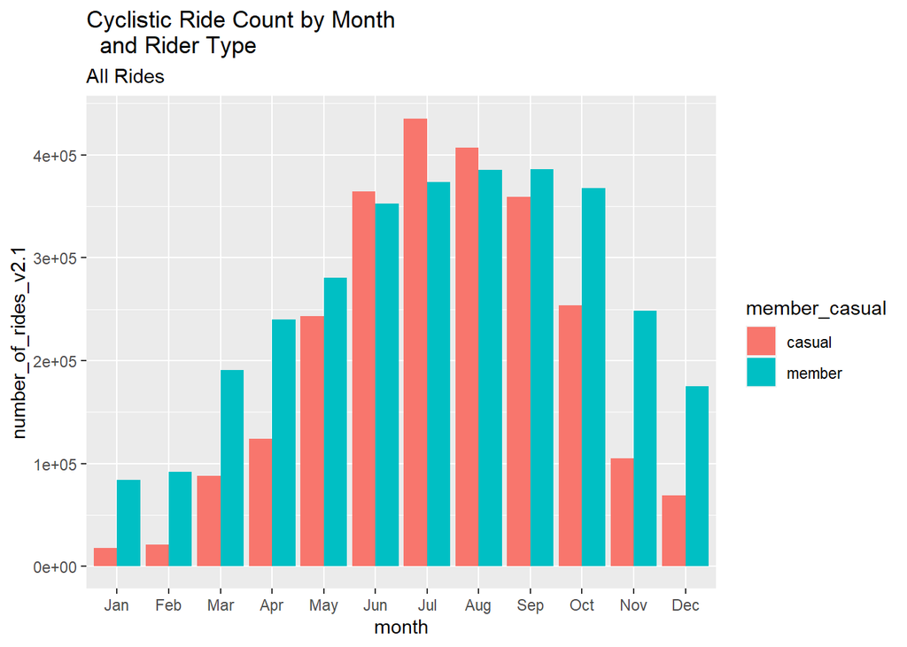

## Executive Summary

**The question** - Identify how member and casual riders use cycles differently

**The Timeframe Analyzed** - June 2021 - May 2022

**Findings**

- Casual riders use bikes for longer periods of time
- Casual riders ride more than members on weekends
- Casual riders use “docked” bikes, members do not
- Casual Riders Use Bikes In Good Weather

**Recommendations**

- Identify repeat casual riders and/or demographics within this group
  - Create a focus group to determine why they don’t become members
- Aggregate data to enable a heat map of rides within the city
  - How are rider types distributed throughout the city
- Determine if there is an accessibility issue - identify an unmet need for casual riders
  - Since casual riders use docked bikes, whereas members do not
  - Casual riders ride longer - do they cover more distance or do they simply ride slower

## Appendix

### Rides can be as long as 55,944 mins

For reference, that’s longer than a month, which seems odd to be renting a bike This led me down a path to find what drives riders to keep a bike for more than a day

- I found the upper threshold of ride times, 42.5 minutes (anything above this time is an outlier)

Number of rides by day and by member type (data set v2.2, rides less than 42.5 minutes, the upper threshold for outliers in the overall data set)

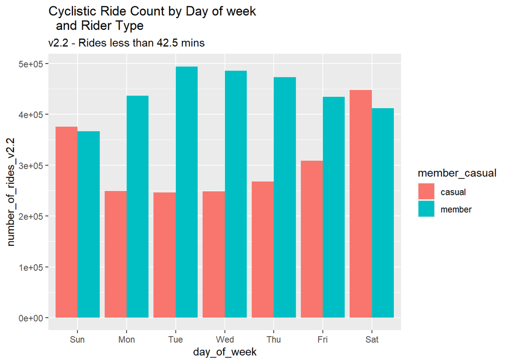

Average ride length by day and by member type

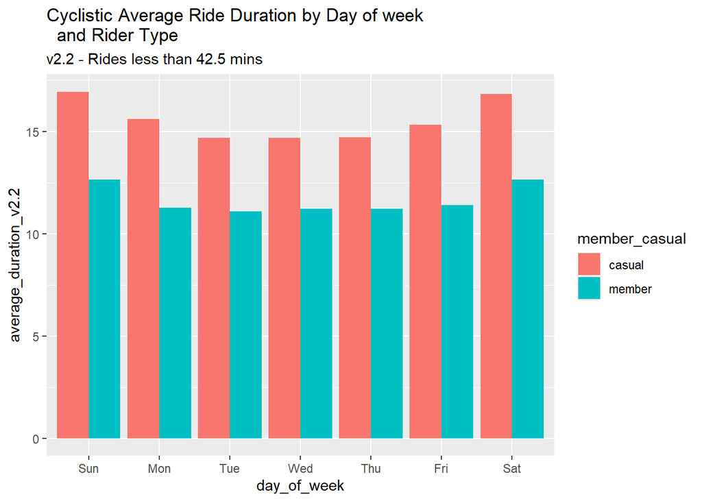

Number of rides by day and by member type (data set v2.3, rides more than 42.5 minutes, the upper threshold for outliers in the overall data set)

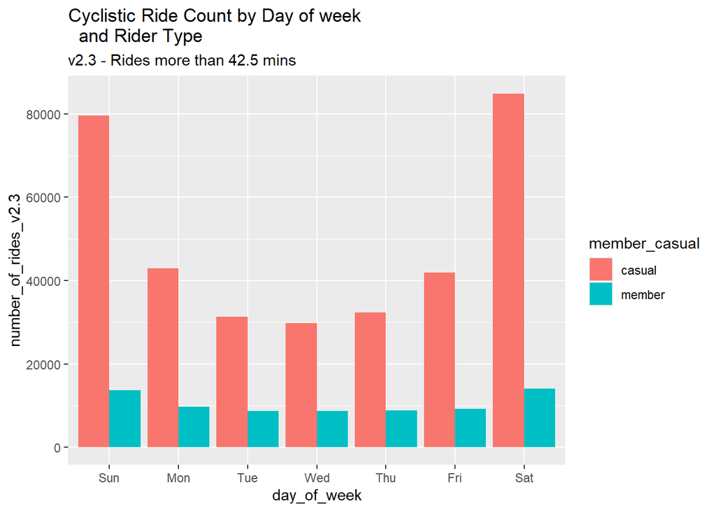

Ride Count by Rideable Type and Member Type

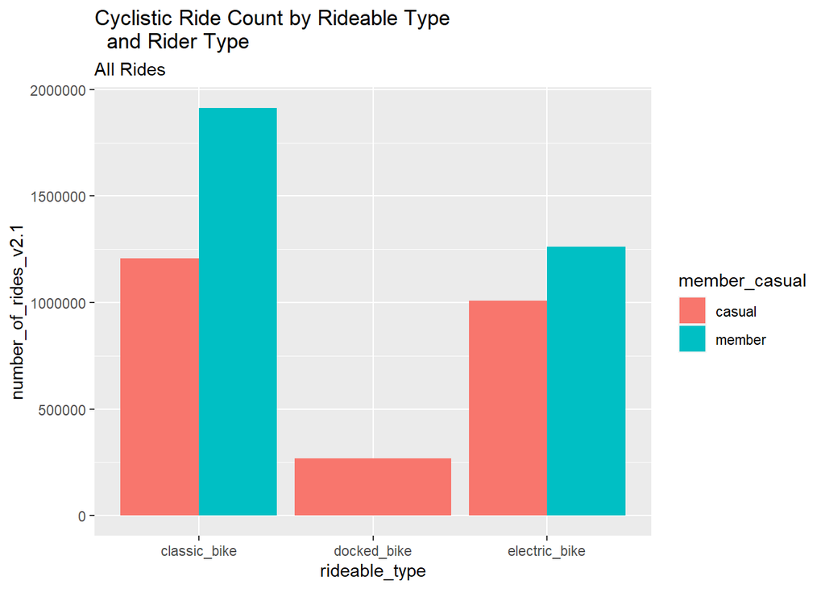

**Findings**

- Rides below 42.5 minutes are predominantly members, riding during the week
- Rides more than 42.5 minutes are predominantly casual, riding on weekends
  - They pick the bikes up on a weekend day…
- Rides more than 42.5 minutes average just above 90 minutes FOR BOTH GROUPS!
  - Casual average duration for this subset is 95 mins
  - Member average duration for this subset is 97 mins

**Takeaways and New Questions**

Takeaways

- Casual riders exhibit member characteristics and vice versa, depending on ride length
- Casual riders and members may use bikes for both commuting and recreation

New Questions

- Why haven’t certain casual riders become members?
  - Especially those where ride length is “short,” which suggests they are commuting
- Do members use bikes for commuting AND recreation???
  - Are members more likely to turn in bikes and take a new one during the same day?
  - Perhaps take a different bike for lunch break, etc, which would drive a longer ride length
- Do casual riders hang onto bikes longer because there is an extra step for them to get a different one?

## Create .csv files for visualizations in programs other than R

Output not included, eval set to FALSE

```r
ridecounts_day_type <- aggregate(all_trips_v2.1$ridelength ~ all_trips_v2.1$member_casual + all_trips_v2.1$weekday, FUN = length)
write.csv(ridecounts_day_type, file = '~ride_count_day_type.csv')

ridelengths_day_type <- aggregate(all_trips_v2.1$ridelength ~ all_trips_v2.1$member_casual + all_trips_v2.1$weekday, FUN = mean)
write.csv(ridelengths_day_type, file = '~avg_ride_length_day_type.csv')

ridelengths_month_type <- aggregate(all_trips_v2.1$ridelength ~ all_trips_v2.1$member_casual + all_trips_v2.1$month, FUN = mean)
write.csv(ridelengths_month_type, file = '~ride_length_month_type.csv')

ridelengths_rideable_type <- aggregate(all_trips_v2.1$ridelength ~ all_trips_v2.1$member_casual + all_trips_v2.1$rideable_type, FUN = mean)
write.csv(ridelengths_rideable_type, file = '~ride_length_rideable_type.csv')
```